# Lab 5: Machine Learning I

In this lab, we will practice working with machine learning terminology and modeling approaches for bianry classification. We will fit a logistic regression and a Naive Bayes classifier to breast cancer biopsy data from the University of Wisconsin. This dataset is available as `brca` in the `dslabs` package and is also part of the UCI Machine Learning Repository. `brca` is a binary classification dataset for 569 malignant (cancer) and benign (not cancer) breast masses. 30 continuous features were computationally extracted from digital images of fine needle aspirate biopsy slides.

```r
library(tidyverse)
library(caret)
library(dslabs)
library(splitstackshape)
library(e1071)
data(brca)
```

For simplicity, let’s focus on only the first two predictors, `radius_mean` and `texture_mean`. In the code chunk below, we construct a data frame called `data` with four variables:

- `labels`: a factor with two levels denoting whether a mass is “Benign” or “Malignant”. This will be useful for summarizing and plotting the data.
- `y`: a numeric vector that encodes the outcomes as 0 for Benign and 1 for Malignant. This will be useful for model fitting.
- `radius_mean`: the mean nucleus radius
- `texture_mean`: the mean nucleus texture

```r
data = data.frame(labels = factor(ifelse(brca$y == "B", "Benign", "Malignant")),
                  y = ifelse(brca$y == "B", 0, 1),
                  radius_mean = brca$x[,"radius_mean"],
                  texture_mean = brca$x[,"texture_mean"])
```

Run the code below to create training and test sets. We will use a 70% training, 30% test set split. Note that we have an imbalance in outcome groups (212/569 = 37% of masses are malignant and 63% are not), so we need to take this into account when we split our data into training and test sets. Here we use the function `stratified` from the `splitstackshape` package to split the data. The stratified function samples the same percent of individuals from each class - in this case, `y`. Finally, `set.seed(219)` ensures reproducibility, so that we get the same random split every time we run the code.

```r
set.seed(219)

x           <- stratified(data, "y", 0.7, keep.rownames = TRUE)
train_set   <- x %>% dplyr::select(-rn) # Remove row numbers
train_index <- as.numeric(x$rn)
test_set    <- data[-train_index,]
test_set_y  <- as.factor(test_set$y)

head(train_set)
```

```
##    labels     y radius_mean texture_mean
##    <fctr> <num>       <num>        <num>
## 1: Benign     0       12.80        17.46
## 2: Benign     0       12.34        14.95
## 3: Benign     0       11.27        15.50
## 4: Benign     0       13.28        13.72
## 5: Benign     0       13.64        15.60
## 6: Benign     0       10.08        15.11
```

```r
head(test_set)
```

```
##    labels y radius_mean texture_mean
## 4  Benign 0      13.030        18.42
## 11 Benign 0      11.520        18.75
## 12 Benign 0      13.050        19.31
## 13 Benign 0       8.618        11.79
## 14 Benign 0      10.170        14.88
## 20 Benign 0      12.780        16.49
```

1. Before doing any model fitting, it is always a good idea to perform some exploratory data analysis. Based on the training set, calculate summary statistics and make plots to help you get a better sense of the data. In particular, use your explorations to comment on the prevalence of the outcome, the relationships between the variables, and anything that you would consider unusual.

**Solution:**

(Note that this solution is non-exhaustive, and that there are many other things that you could do as part of your EDA.)

Here’s a quick way to get summary statistics for every variable in the data frame.

```r
train_set %>% summary()
```

```
##        labels          y           radius_mean      texture_mean
##  Benign   :250   Min.   :0.0000   Min.   : 7.691   Min.   : 9.71
##  Malignant:148   1st Qu.:0.0000   1st Qu.:11.760   1st Qu.:16.02
##                  Median :0.0000   Median :13.370   Median :18.81
##                  Mean   :0.3719   Mean   :14.200   Mean   :19.32
##                  3rd Qu.:1.0000   3rd Qu.:15.977   3rd Qu.:21.98
##                  Max.   :1.0000   Max.   :27.420   Max.   :39.28
```

You could have gotten the prevalence of the outcome directly from the summary statistics above, or you could calculate it like this:

```r
mean(train_set$y)
```

```
## [1] 0.3718593
```

or like this

```r
train_set %>%
  summarize(pi = mean(labels=="Malignant")) %>%
  .$pi
```

```
## [1] 0.3718593
```

As you can see, there is a lower prevalence of malignant masses compared to benign masses in this dataset.

Histograms can give us a quick snapshot of the univariate distributions of the two continuous predictors. Both `radius_mean` and `texture_mean` look roughly unimodal and symmetric, although both have a longer right tail.

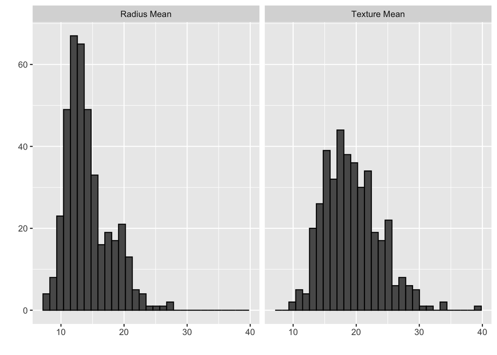

```r
train_set %>%
  gather(feature_name, measurement, c("radius_mean", "texture_mean"))  %>%
  ggplot(aes(measurement)) +
  geom_histogram(color = "black") +
  facet_grid(~feature_name,
             labeller = as_labeller(c("radius_mean"="Radius Mean",
                                      "texture_mean" = "Texture Mean"))) +
  xlab("") +
  ylab("")
```

These boxplots suggest that malignant masses generally correspond to higher values of both the `radius_mean` and `texture_mean` variables.

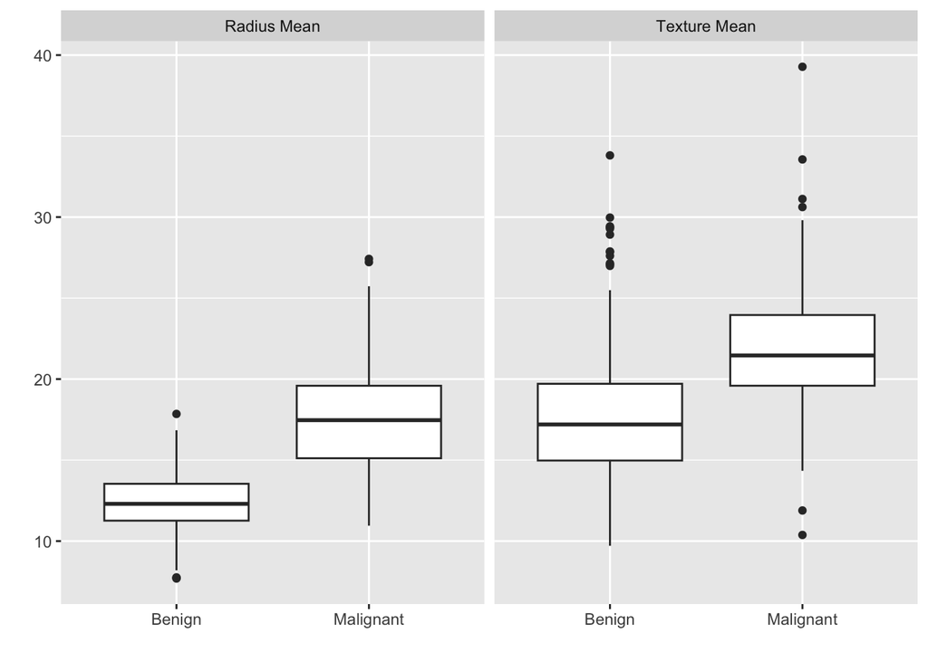

```r
train_set %>%
  gather(feature_name, measurement, c("radius_mean", "texture_mean"))  %>%
  ggplot(aes(x = labels, y = measurement)) +
  geom_boxplot() +
  facet_wrap(~ feature_name,
             labeller = as_labeller(c("radius_mean"="Radius Mean",
                                      "texture_mean" = "Texture Mean"))) +
  xlab("") +
  ylab("")
```

Instead of making side-by-side boxplots, we can visualize the outcome and predictors in a single plot by making good use of color. This scatterplot graphs `texture_mean` against `radius_mean` and colors the points according to the outcome labels. The two different classes form distinct, but not totally separable groups of points. Some observations look like they might be difficult to classify.

```r
# Mean of each predictor by outcome value
train_set %>%
  group_by(y) %>%
  summarise('mean_radius' = mean(radius_mean),
            'mean_texture' = mean(texture_mean))
```

```
## # A tibble: 2 × 3
##       y mean_radius mean_texture
##   <dbl>       <dbl>        <dbl>
## 1     0        12.3         17.9
## 2     1        17.5         21.8
```

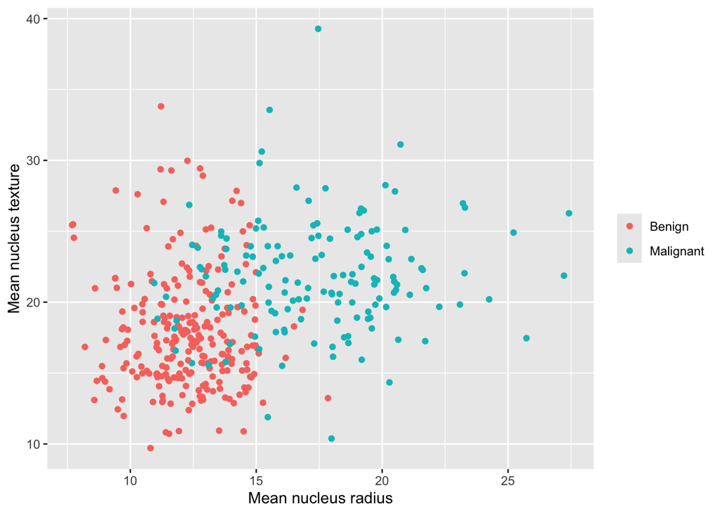

```r
# Scatterplot coloring by outcome
ggplot(train_set, aes(x = radius_mean, y = texture_mean)) +
  geom_point(aes(color = labels)) +
  labs(x = "Mean nucleus radius",
       y = "Mean nucleus texture") +
  theme(legend.title=element_blank())
```

2. Using the `glm` function, fit a logistic regression model to the training set that predicts `y` based on `radius_mean` and `texture_mean`. Don’t forget to set `family = "binomial"`. Then, use the `predict` function to get predicted probabilities for the test set, and convert the probabilities to predicted response labels (use a cutoff of 0.5).

Obtain the accuracy, confusion matrix, and other relevant diagnostic statistics for the test set. Explain what the confusion matrix and the sensitivity/specificity are telling you about the types of errors that your model is making.

**Solution:**

```r
### Fit Model
model_LR <- glm(y ~ radius_mean + texture_mean, data = train_set, family = 'binomial')

### Make Predictions
prob_malignant <- predict(model_LR, newdata = test_set, type = 'response')

test_set$prob_malignant_LR <- prob_malignant

test_set$pred_label_LR <- ifelse(test_set$prob_malignant_LR > 0.5, 1, 0)

test_set$pred_label_text_LR <- ifelse(test_set$prob_malignant_LR > 0.5, 'Malignant', 'Benign')
```

```r
# Print confusion matrix
confusionMatrix(data = as.factor(test_set$pred_label_text_LR),
                reference = test_set$labels,
                positive = "Malignant")
```

```
## Confusion Matrix and Statistics
##
##            Reference
## Prediction  Benign Malignant
##   Benign       102        11
##   Malignant      5        53
##
##                Accuracy : 0.9064
##                  95% CI : (0.8525, 0.9456)
##     No Information Rate : 0.6257
##     P-Value [Acc > NIR] : <2e-16
##
##                   Kappa : 0.7964
##
##  Mcnemar's Test P-Value : 0.2113
##
##             Sensitivity : 0.8281
##             Specificity : 0.9533
##          Pos Pred Value : 0.9138
##          Neg Pred Value : 0.9027
##              Prevalence : 0.3743
##          Detection Rate : 0.3099
##    Detection Prevalence : 0.3392
##       Balanced Accuracy : 0.8907
##
##        'Positive' Class : Malignant
##
```

3. Using the `naiveBayes` function, fit a Naive Bayes model to the training set that predicts `y` based on `radius_mean` and `texture_mean`. Then, use the `predict` function to get probability estimates for the test set, and convert the probabilities to predicted response labels.

When you are done, obtain the accuracy, confusion matrix, and other relevant diagnostic statistics for the test set. Compare the performance of your Naive Bayes model with the logistic regression model from Q2.

**Solution:**

```r
model_NB  <- naiveBayes(y ~ radius_mean + texture_mean, data = train_set)
p_hat_nb <- predict(model_NB, test_set, type = "raw")[,2]
y_hat_nb <- predict(model_NB, test_set)

test_set$prob_malignant_NB <- p_hat_nb

test_set$pred_label_NB <- ifelse(test_set$prob_malignant_NB > 0.5, 1, 0)

test_set$pred_label_text_NB <- ifelse(test_set$prob_malignant_NB > 0.5, 'Malignant', 'Benign')

confusionMatrix(data = as.factor(test_set$pred_label_text_NB), reference = test_set$labels, positive = "Malignant")
```

```
## Confusion Matrix and Statistics
##
##            Reference
## Prediction  Benign Malignant
##   Benign       103        18
##   Malignant      4        46
##
##                Accuracy : 0.8713
##                  95% CI : (0.8117, 0.9176)
##     No Information Rate : 0.6257
##     P-Value [Acc > NIR] : 7.144e-13
##
##                   Kappa : 0.7127
##
##  Mcnemar's Test P-Value : 0.005578
##
##             Sensitivity : 0.7188
##             Specificity : 0.9626
##          Pos Pred Value : 0.9200
##          Neg Pred Value : 0.8512
##              Prevalence : 0.3743
##          Detection Rate : 0.2690
##    Detection Prevalence : 0.2924
##       Balanced Accuracy : 0.8407
##
##        'Positive' Class : Malignant
##
```

The predicted probabilities from the two models also line up closely with each other.

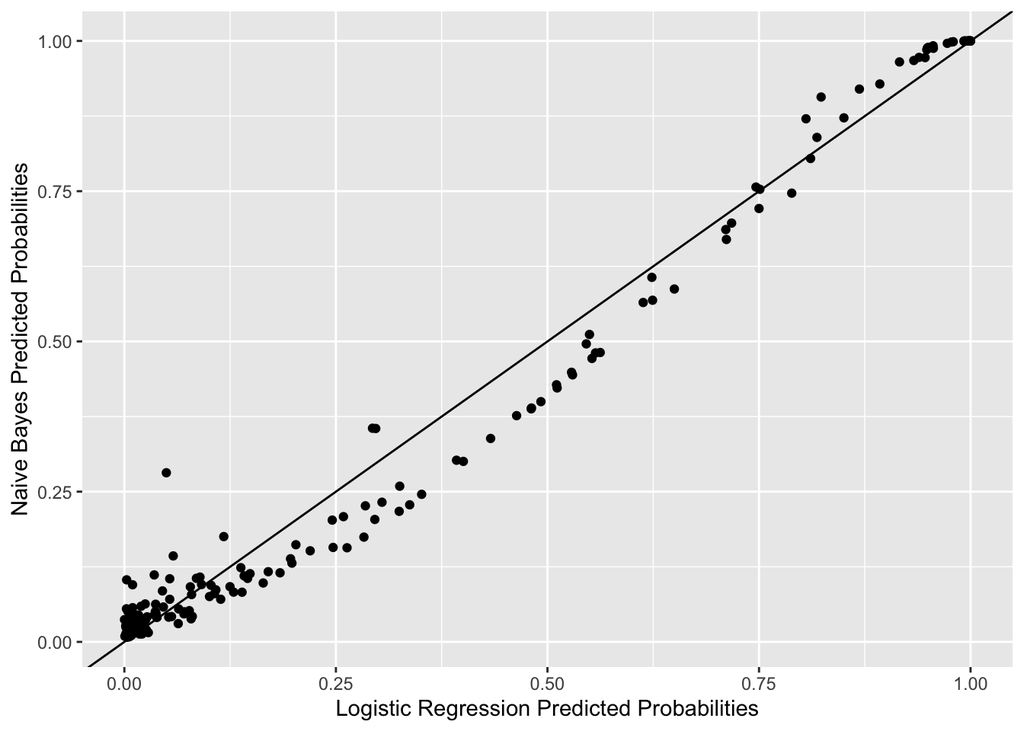

```r
test_set %>% ggplot(aes(prob_malignant_LR, prob_malignant_NB)) +
  geom_point() +
  geom_abline() +
  labs(x = "Logistic Regression Predicted Probabilities",
       y = "Naive Bayes Predicted Probabilities")
```

4. Make a scatterplot of `radius_mean` vs. `texture_mean` in the test dataset. Color the points that both models classify as “Benign” in one color, the points that both models classify as “Malignant” in a second color, and the points where the models disagree in a third color. Based on this visualization, does it make sense that these observations are the ones that the two classifiers did not agree on? Do these observations tend to belong to a particular outcome class?

**Solution:**

The `case_when` function in the `dplyr` package makes it easy to create a vector with multiple cases. This is much cleaner than having a bunch of nested ifelse statements.

```r
test_set <- test_set %>%
  mutate(concordance_labels = case_when(
   pred_label_text_LR == "Benign" & pred_label_text_NB == "Benign" ~ "Both Benign",
   pred_label_text_LR == "Malignant" & pred_label_text_NB == "Malignant" ~ "Both Malignant",
   TRUE ~ "Disagree"
))
```

Looking at the scatterplot, it is apparent that the observations where the two models disagree fall more-or-less directly on the decision boundary. This is exactly where you would expect there to be uncertainty and less robustness. It doesn’t really seem that these observations correspond to higher/lower values of the predictors.

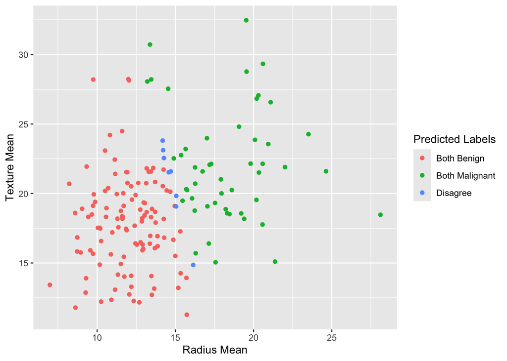

```r
test_set %>% ggplot(aes(radius_mean, texture_mean, color = concordance_labels)) +
  geom_point() +
  scale_color_discrete(name = "Predicted Labels") +
  xlab("Radius Mean") + ylab("Texture Mean")
```

```r
test_set %>% filter(concordance_labels == "Disagree")
```

```
##      labels y radius_mean texture_mean prob_malignant_LR pred_label_LR
## 1    Benign 0       16.14        14.86         0.5458755             1
## 2 Malignant 1       14.58        21.53         0.5296186             1
## 3 Malignant 1       14.71        21.59         0.5623298             1
## 4 Malignant 1       15.06        19.83         0.5525899             1
## 5 Malignant 1       14.22        23.12         0.5284575             1
## 6 Malignant 1       14.19        23.81         0.5567879             1
## 7 Malignant 1       15.05        19.07         0.5114349             1
## 8 Malignant 1       14.27        22.55         0.5107092             1
##   pred_label_text_LR prob_malignant_NB pred_label_NB pred_label_text_NB
## 1          Malignant         0.4958926             0             Benign
## 2          Malignant         0.4443370             0             Benign
## 3          Malignant         0.4815506             0             Benign
## 4          Malignant         0.4716852             0             Benign
## 5          Malignant         0.4486411             0             Benign
## 6          Malignant         0.4808845             0             Benign
## 7          Malignant         0.4225553             0             Benign
## 8          Malignant         0.4278186             0             Benign
##   concordance_labels
## 1           Disagree
## 2           Disagree
## 3           Disagree
## 4           Disagree
## 5           Disagree
## 6           Disagree
## 7           Disagree
## 8           Disagree
```